# Bold Vision Youth Thriving Survey

Total Trends by Component, Subcomponent, and Question

Catalyst California in collaboration with Bold Vision

03 December, 2024

The following summarizes how all youth responded to each question in the Bold Vision Youth Thriving Survey by component and subcomponent measured. The distribution of responses to each question within each subcomponent (e.g., Positive Emotions) is visualized using either a heatmap or table. The percentages shown are based on weighted estimates that adjust the Youth Thriving sample by age, sex, race, and Service Planning Area. Estimates that have a coefficient of variation greater than 40% are regarded as unstable and are suppressed from the heatmaps.

A total of 3,444 youth ages 15-24 in Los Angeles County completed the survey.

For a corresponding analysis by race, see [Trends by Race and Question](https://catalystcalifornia.github.io/boldvision_youththriving/Descriptive%20and%20Demographic%20Analyses/analysis_by_race).

# Strong Minds (and Bodies)

Component definition: Youth with positive mental and physical health, which includes but is not limited to positive emotions, health behaviors, cognitive development, and accessible resources that promote overall well-being for youth. Note not every aspect is measured in the Youth Thriving Survey.

## Positive Emotions

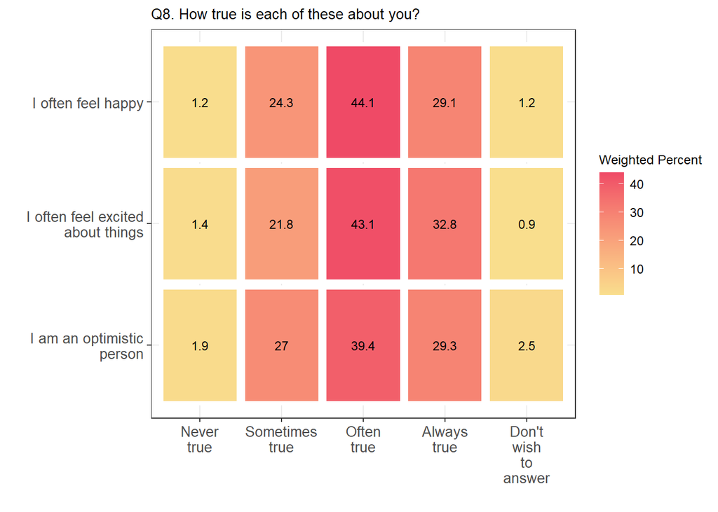

## Growth Mindset

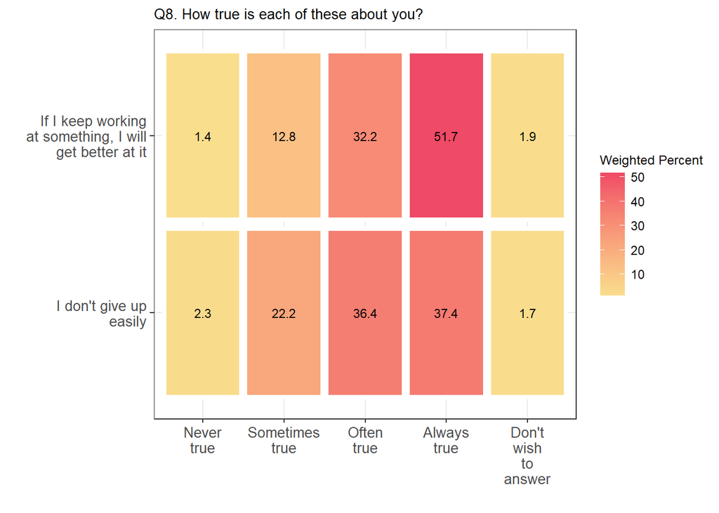

## Psychological Distress

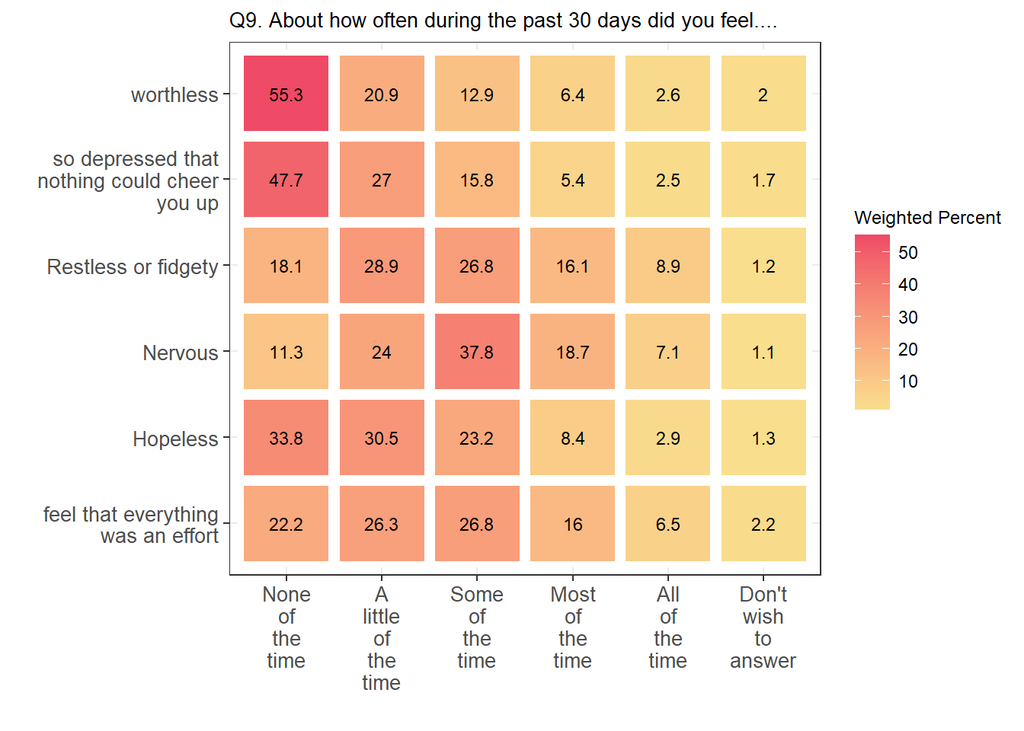

# Positive Identity And Self-Worth

Component definition: Youth having a strong sense of self, self-worth, and hope for the future. It can include things like hope for the future, purpose, and self-efficacy.

## Self-Efficacy

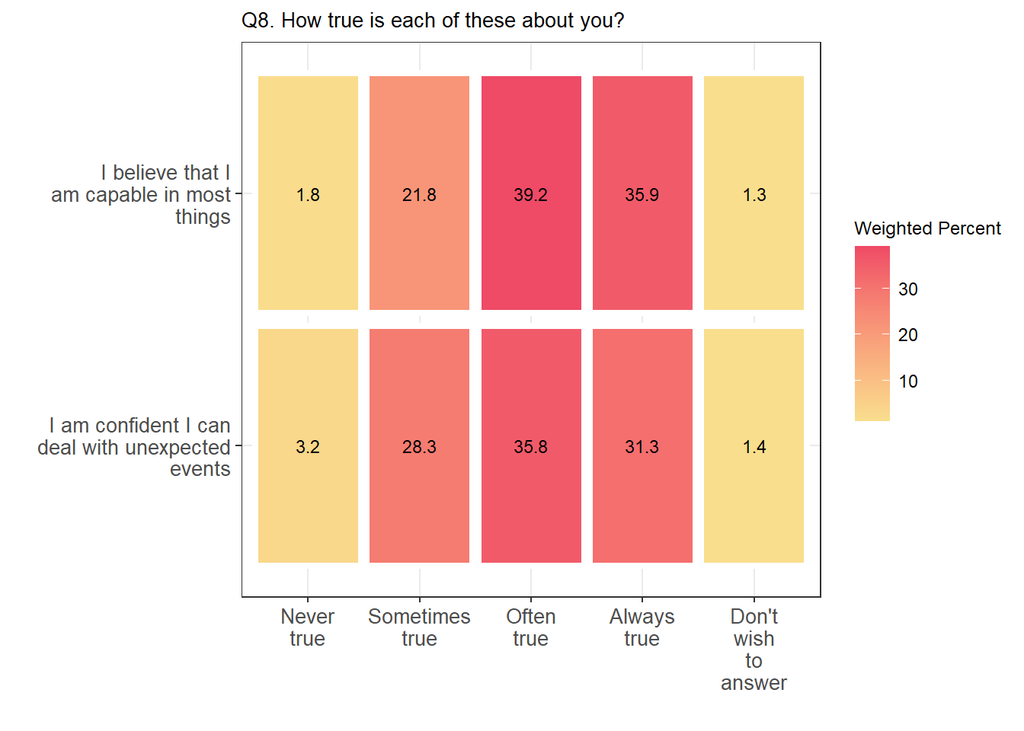

## Hope For The Future

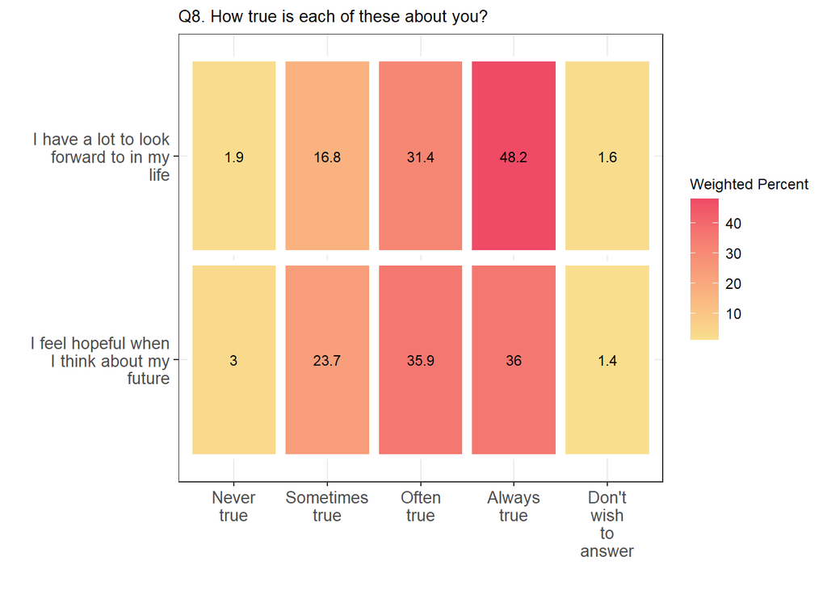

## Freedom To Explore Self

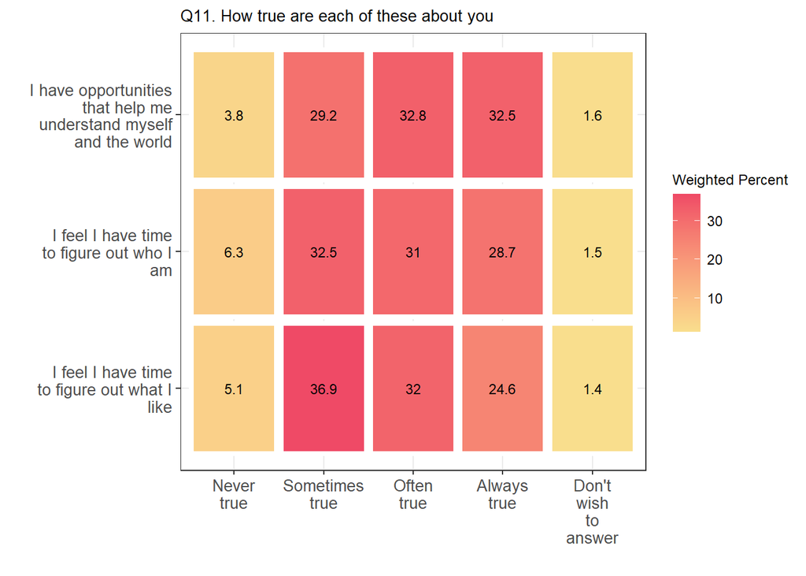

## Sparks

Q10. When people are really happy, energized, and passionate about their talents, interests, or hobbies, we say they have a “spark” in their life., Do you have this kind of spark in your life?

| RESPONSE | FREQUENCY | PERCENT |
| --- | --- | --- |
| Yes | 2460 | 73.2 |
| No | 214 | 6.0 |
| Not sure | 675 | 18.6 |
| Don’t wish to answer | 95 | 2.2 |

Q10b. Which of the following are reasons that you are not more involved with your talents, interests, or hobbies?

| RESPONSE | FREQUENCY | PERCENT |
| --- | --- | --- |
| I dont know what my talents, interests, or hobbies are | 61 | 30.07 |
| I dont have enough time for them | 33 | 14.70 |
| I dont have enough money to pay for the equipment, supplies, lessons, etc | 32 | 13.76 |
| I dont know how to get more involved with them | 14 | 8.59 |
| I feel I cant pursue them because of my race, appearance, and or gender | 8 | 4.90 |
| I feel too sad or anxious to figure them out | 23 | 12.29 |
| I dont feel its safe to explore them | 3 | 0.80 |
| I dont have access to the resources to get more involved with them | 8 | 6.39 |
| I dont have the support from my family, friends, or community to pursue them | 6 | 0.39 |
| Other | 10 | 3.51 |
| Not sure | 7 | 1.56 |
| Don’t wish to answer | 9 | 3.02 |

## Critical Action

Q13. How true are each of these about you?, There are ways for me to get involved in my community

| RESPONSE | FREQUENCY | PERCENT |
| --- | --- | --- |
| Never true | 154 | 4.4 |
| Sometimes true | 761 | 19.9 |
| Often true | 1165 | 34.2 |
| Always true | 1250 | 39.0 |
| Don’t wish to answer | 114 | 2.4 |

# Caring Families And Relationships

Component definition: Relational aspects of youth thriving such as friendships, caregiver relationships, school relationships, and more to identify the caring, stable, and positive relations in a youth’s network.

## Relationships And Support

Q10a. How many adults really know what your sparks are and help you go after them?

| RESPONSE | FREQUENCY | PERCENT |
| --- | --- | --- |
| None | 303 | 9.4 |
| One | 432 | 13.9 |
| Two | 821 | 26.5 |
| Three or more | 968 | 30.8 |
| Not Sure | 585 | 16.5 |
| Don’t wish to answer | 121 | 2.9 |

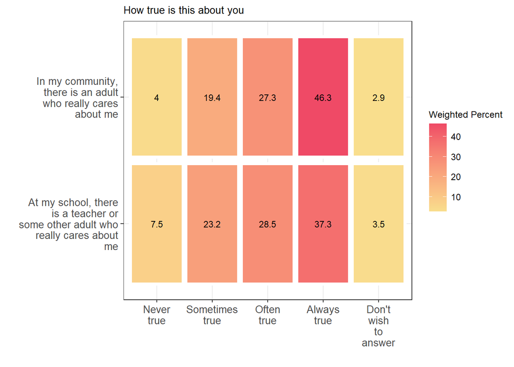

## Connectedness

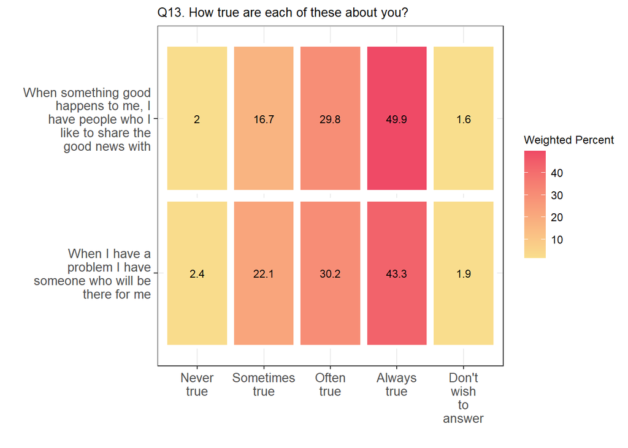

# Cultural Identity

Component definition: The connectedness youth have to their culture/ethnic identity which includes healing practices, ethnic pride and following family traditions.

## Cultural Identity And Connection

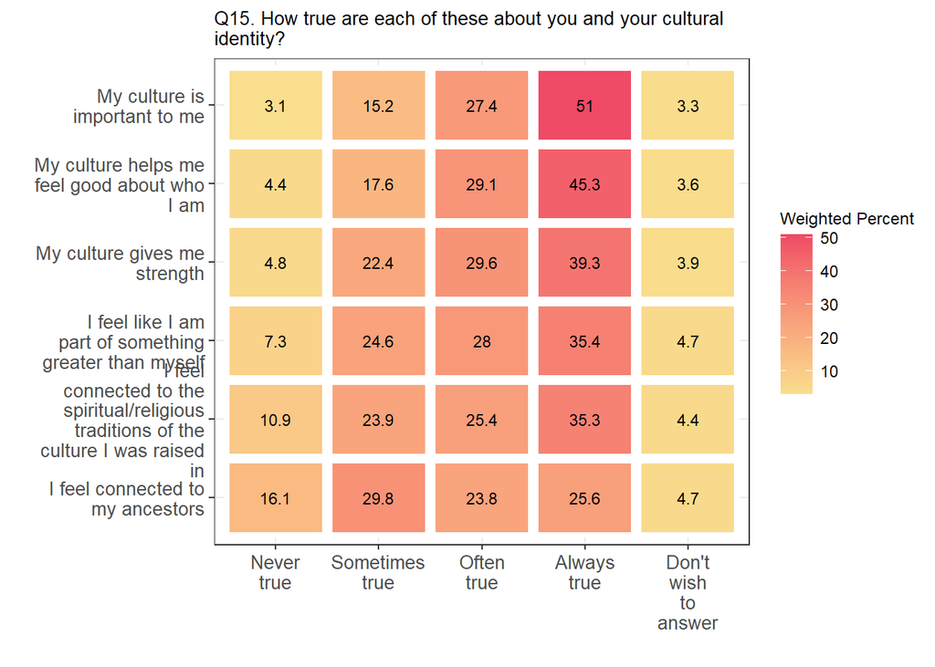

# Safety

Component definition: Safety that youth feel in their neighborhoods, at school, and in their larger communities across physically safe spaces, secure relationships (not fearing bullying, violence or abandonment), and protected development (free to be children). Note not every aspect is measured in the Youth Thriving Survey.

## Personal Safety

Q19. How often do you worry about your own safety while in the neighborhood you live in now?

| RESPONSE | FREQUENCY | PERCENT |
| --- | --- | --- |
| Never | 562 | 20.3 |
| Rarely | 862 | 28.2 |
| Sometimes | 1207 | 32.9 |
| Most of the time | 451 | 10.4 |
| All of the time | 276 | 6.4 |
| Does not apply to me | 86 | 1.8 |

# Vibrant Communities

Component definition: Local resources available to youth such as open public spaces, safe spaces, accessible public transportation, and more.

## Safe Access To Public Spaces

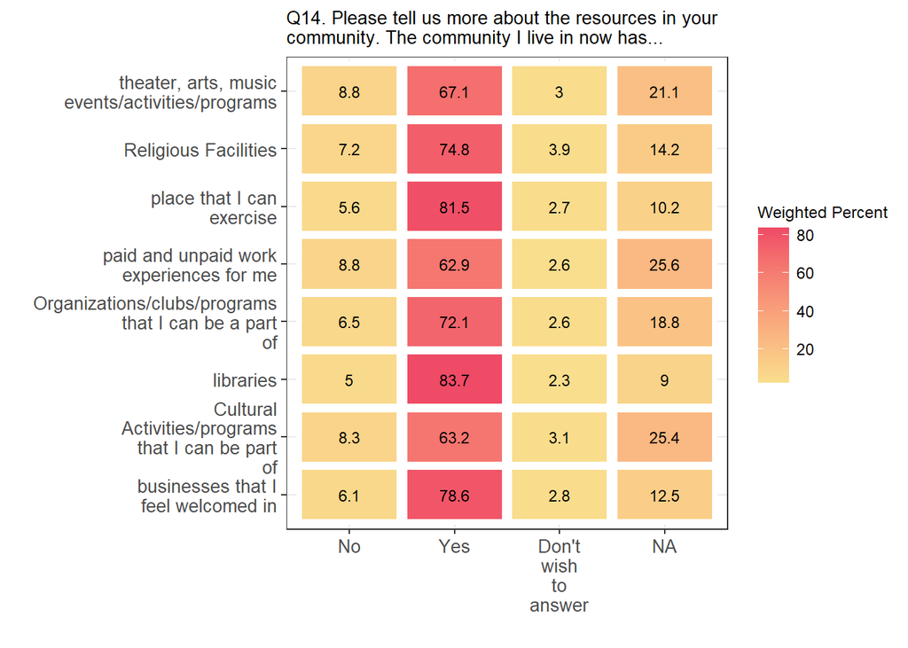

# Racial Justice, Equity, And Inclusion

Component definition: Youth feeling comfortable, accepted, and included in all spaces they enter, regardless of race/ethnicity, gender, religion, health status, and appearance. Youth’s systemic interactions should be fair and equitable irrespective of their identity.

## Microaggressions

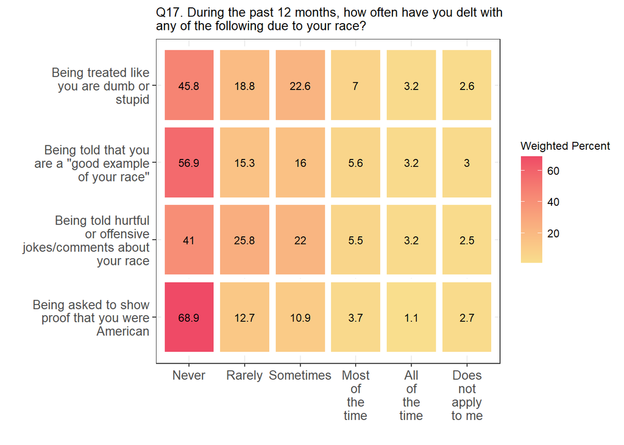

## Experiences of Racism

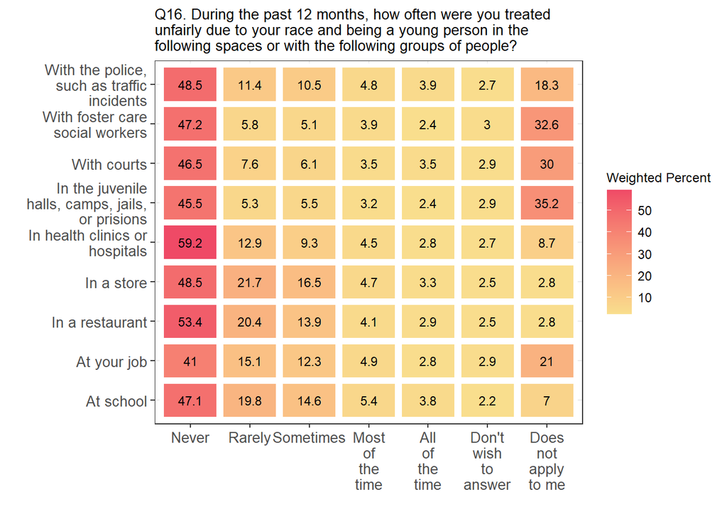

## Structural Racism

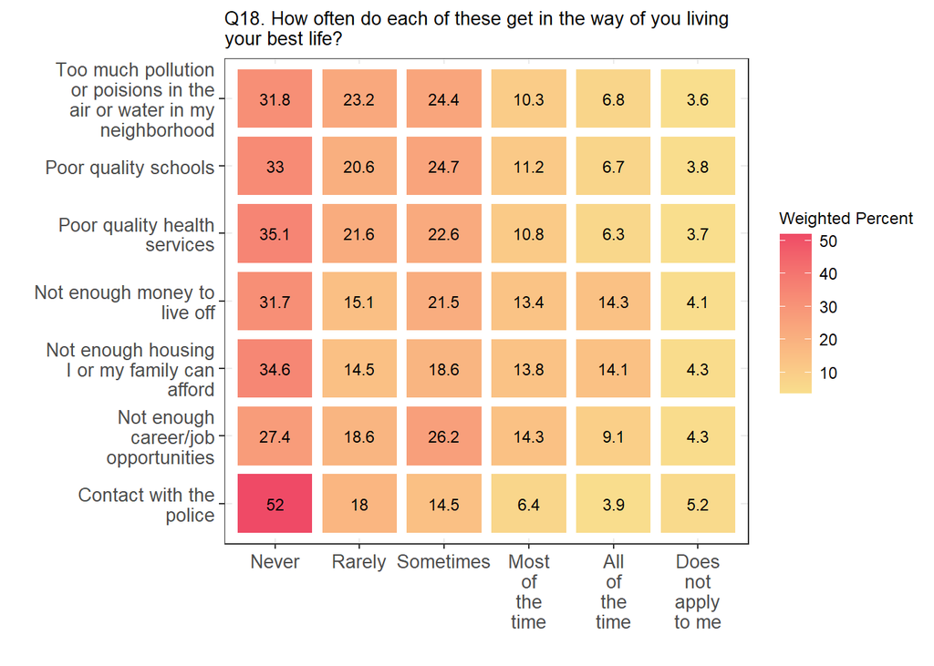